# Assignment_practical_ML

Massimo Zanetti

Thursday, May 14, 2015

# WEIGHT LIFTING EXERCISE RECOGNITION

## ABSTRACT

In order to reproduce the results the [training](https://d396qusza40orc.cloudfront.net/predmachlearn/pml-training.csv) and [test](https://d396qusza40orc.cloudfront.net/predmachlearn/pml-testing.csv) datasets should be saved into the working directory.

## DATA LOADING

We start the analysis loading the required packages.

Then we load the datasets:

```r
    training_full <- read.table( "pml-training.csv" , header = TRUE , sep= ",")
    test_full <- read.table( "pml-testing.csv" , header = TRUE , sep= ",")

    dim ( training_full )
```

```
## [1] 19622   160
```

```r
    dim ( test_full )
```

```
## [1]  20 160
```

Now the datasets are ready to be processed.

## DATA PREPROCESSING

### NAs removal

We see that the datasets contain a lof of NAs values.  
Since only a subset of columns from test set is not NA we focus on valid columns (with less than 20 NAs).

Then we exclude from the analysis the columns X, user_name, raw_timestamp_part_1, raw_timestamp_part_2, cvtd_timestamp, new_window, num_window because we we focus only on data from the sensors.

```r
    valid_columns  <- apply(  test_full , 2 , function(x)  sum(is.na(x)) )!= 20
    training_full <- training_full[,valid_columns ]
    test_full     <- test_full[,valid_columns ]

    training_full <- training_full[,8:60]
    test_full     <- test_full[,8:59]
```

### Near Zero Variance variable

We verify the presence of variables with reduced variability.

```r
    nearZeroVar(training_full , saveMetrics = FALSE )
```

```
## integer(0)
```

```r
    nearZeroVar(test_full , saveMetrics = FALSE )
```

```
## integer(0)
```

We see that there are no problems of zero variance variables.

## EXPLORATORY DATA ANALYSIS

We start the analysis of the training set focusing on a subset of rows to avoid computational problems.

```r
    idx_quarter <- createDataPartition( y=training_full$classe , p= 0.25 ,list=FALSE)
    training <- training_full[idx_quarter,]
```

The dimension of the reduced dataset is now 4907 rows. We verify the presence of correlated variables using a correlogram chart.

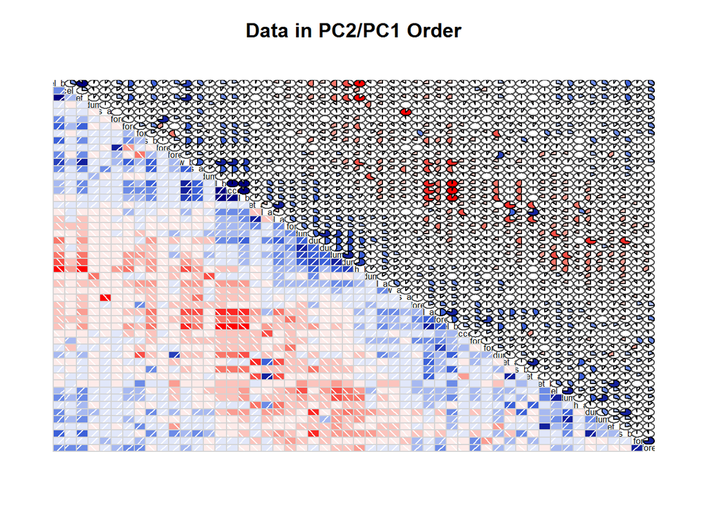

```r
    corrgram(training[,-53], order=TRUE, lower.panel=panel.shade,
      upper.panel=panel.pie, text.panel=panel.txt,
      main="Data in PC2/PC1 Order")
```

We show the variables with highest correlation.

```r
    corr<-cor(training[,-53] )

    diag(corr)<-NA
    corr[upper.tri(corr)]<-NA

    corr <-  melt(corr)
    corr <-  corr[abs(corr$value)>0.8,]
    corr <- corr[!is.na(corr$value),]
    corr <- corr[order(abs(corr$value),decreasing= TRUE),]
    rownames(corr) <- NULL
    kable(corr , digit=2 )
```

```
##
##
## |X1               |X2               | value|
## |:----------------|:----------------|-----:|
## |accel_belt_z     |roll_belt        | -0.99|
## |total_accel_belt |roll_belt        |  0.98|
## |accel_belt_z     |total_accel_belt | -0.97|
## |accel_belt_x     |pitch_belt       | -0.96|
## |accel_belt_z     |accel_belt_y     | -0.93|
## |accel_belt_y     |total_accel_belt |  0.93|
## |accel_belt_y     |roll_belt        |  0.92|
## |gyros_arm_y      |gyros_arm_x      | -0.92|
## |magnet_belt_x    |accel_belt_x     |  0.88|
## |magnet_belt_x    |pitch_belt       | -0.88|
## |accel_dumbbell_z |yaw_dumbbell     |  0.85|
## |yaw_belt         |roll_belt        |  0.81|
## |magnet_arm_z     |magnet_arm_y     |  0.81|
## |magnet_arm_x     |accel_arm_x      |  0.81|
## |accel_dumbbell_x |pitch_dumbbell   |  0.80|
```

We end the data exploration plotting the observations using the first 2 principal components.

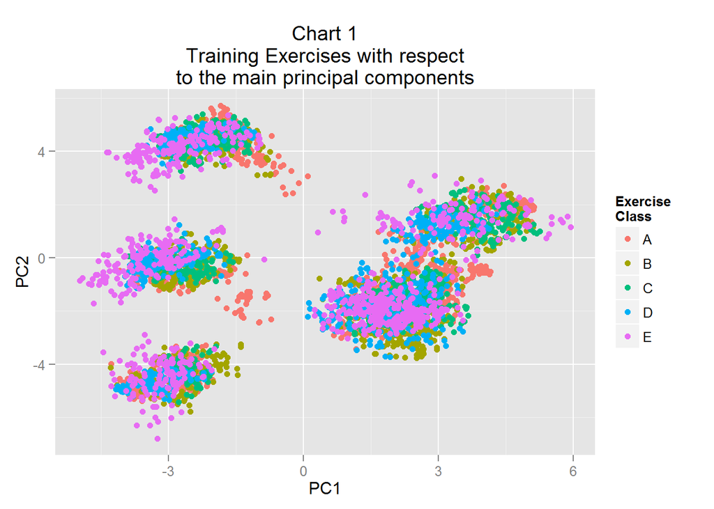

```r
    procPCA <- preProcess(training[,-53] , method='pca' )
    training_pca <- predict ( object= procPCA , newdata= training[,-53]   )

    ggplot (  training_pca , aes( x= PC1 , y= PC2 , color=  training$classe ) ) +
      geom_point( )+
      labs(title= "Chart 1\nTraining Exercises with respect\nto the main principal components")+
      scale_colour_discrete(name  ="Exercise\nClass")
```

Chart 1 shows a pattern of 5 diffent clouds of points. Inside each cloud the 5 classes overlap.

## MODEL SELECTION

In this project we examine 3 different classification models:  
* GLM stepwise regression with original variables  
* GLM stepwise regression with principal components  
* Random Forest

The final model will be selected using 5 fold cross validation accuracy metric.  
First of all we compute the benchmark classification performance using 2 criteria for prediction:  
the modal class prediction and the proportional probability prediction.  
The modal class prediction classifies every observation using the most frequent class in the dataset.  
The proportional probability correctly predicts each class using the relative frequency ratio of the class.

### Benchmark classification

```r
    model_accuracy <- data.frame(model=character(5), accuracy=numeric(5))
    set.seed( 647 )
    idx <- sample ( 1:5 , nrow(training) , replace=TRUE ) # fold index
    predicted_accuracy_bench_modal <- predicted_accuracy_bench_prop <- numeric ( 5 )

    for( fo in 1:5 ) # fold
    {
      train_idx <- idx != fo
      test_idx  <- idx == fo
      prediction_benchmark_modal <- prediction_benchmark_prop <- array( NA, dim= c(sum(test_idx),5) )

      prediction_benchmark_modal <- names(which.max( table(training[train_idx,"classe"]) ))
      predicted_accuracy_bench_modal[fo] <- sum ( diag( table ( rep(prediction_benchmark_modal,nrow(training[test_idx,])) , training[test_idx,"classe"] ) ) ) / nrow(training[test_idx,])  # 0.2844617
      predicted_accuracy_bench_prop[fo] <-  sum( round( table(training[test_idx,"classe"]) * prop.table(table(training[test_idx,"classe"]) ),0 ) ) / nrow(training[test_idx,])  # 0.2844617
    }

    model_accuracy$model  <- "modal benchmark"
    model_accuracy$accuracy  <- mean ( predicted_accuracy_bench_modal )

    model_accuracy$model[2]  <-  "prop.prob. benchmark"
    model_accuracy$accuracy[2]  <- mean ( predicted_accuracy_bench_prop )
```

### GLM Stepwise regression with original variables

We perform stepwise logstic regression model starting from only intercept model and sequentially  
adding/removing variables using AIC metric. We use the one-vs-all method to identify the response variable. We compute accuracy in 5 fold cross validation.

```r
      set.seed( 647 )
      idx <- sample ( 1:5 , nrow(training) , replace=TRUE ) # fold index
      predicted_accuracy_step <- numeric ( 5 )

      for( fo in 1:5 ) # fold
      {
        train_idx <- idx != fo
        test_idx  <- idx == fo
        prediction <- array ( NA, dim= c(sum(test_idx),5)  )

        # fo <- 1
        for( f in 1:5 ) {
                  y <- factor(training$classe == levels( training$classe )[f])    # choose outcome
                  fmla <- as.formula( paste( "y[train_idx]" ,  paste(colnames(training)[-53] ,sep="",collapse="+") , sep= "~" )  )
                  fit_glm <- glm( y[train_idx]~ 1  , data= training[train_idx,-53]  , family="binomial" )
                  fit_step <- step( fit_glm  , scope = fmla , direction= "both" , k=2 )

                  # probability of classe y
                  prediction[,f] <- predict( fit_step , newdata= training[test_idx,-53] , type="response")
                  cat("Response: " , f , "\n")
                }

        predicted_class <- levels( training$classe ) [ apply( prediction , 1 , which.max ) ]
        predicted_accuracy_step[fo] <- sum ( diag( table(predicted_class , training[test_idx,"classe"]))) / nrow(training[test_idx,])
        cat("Fold: " , fo , "\n")
      }

    model_accuracy$model[3]  <- "GLM stepwise"
    model_accuracy$accuracy[3]  <- mean ( predicted_accuracy_step )
```

### GLM Stepwise regression with princicpal components

We perform stepwise logstic regression model starting from only intercept model and sequentially  
adding/removing variables using AIC metric. The model is built using the principal components. We use the one-vs-all method to identify the response variable. We compute accuracy in 5 fold cross validation.

```r
    set.seed( 647 )
    idx <- sample ( 1:5 , nrow(training) , replace=TRUE ) # fold index
    predicted_accuracy_step_pca <- numeric ( 5 )

    for( fo in 1:5 ) # fold
    {
      train_idx <- idx != fo
      test_idx  <- idx == fo
      prediction_pca <- array ( NA, dim= c(sum(test_idx),5)  )

      procPCA <- preProcess(training[,-53] , method='pca' )
      training_pca <- predict ( object= procPCA , newdata= training[ train_idx ,-53]   )
      test_pca <- predict ( object= procPCA , newdata= training[ test_idx ,-53] )

      for( f in 1:5 ) {
        y <- factor( training$classe == levels( training$classe )[f])    # choose outcome
        fmla <- as.formula( paste( "y[train_idx]" ,  paste(colnames(training_pca) ,sep="",collapse="+") , sep= "~" )  )
        fit_glm_pca <- glm( y[train_idx]~ 1  , data= training_pca  , family="binomial" )
        fit_step_pca <- step( fit_glm_pca  , scope = fmla , direction= "both" , k=2 )

        # probability of classe y
        prediction_pca[,f] <- predict( fit_step_pca , newdata= test_pca , type="response")
        cat("Fold: " , fo , "\n")
        cat("Response: " , f , "\n")
      }
      predicted_class_pca <- levels( training$classe ) [ apply( prediction_pca , 1 , which.max ) ]
      predicted_accuracy_step_pca[fo] <- sum ( diag( table(predicted_class_pca , training[ test_idx ,"classe"]))) / nrow(test_pca)
    }

    model_accuracy$model[4]  <- "GLM stepwise PCA"
    model_accuracy$accuracy[4]  <- mean ( predicted_accuracy_step_pca )
```

### RANDOM FOREST

We train the random forest model using a reduced dataset.  
We find the best parameter regarding the number of variables analyzed at each node. We run the algorithm in parallel to get faster results.

```r
      cl <- makeCluster(spec= 4, type = getClusterOption("type") )
      registerDoSNOW(cl)
      ## All subsequent models are then run in parallel

      fr_grid <- data.frame( mtry=c( 2:7,seq(8,20,by=2),30) )  # 15    0.9779885

      set.seed( 647 )

      fit_rf <- train( classe~ .  , data= training , method="rf" ,
                       trControl= trainControl(method="cv",number=5) ,
                       tuneGrid=fr_grid ,
                       prox=TRUE, allowParallel=TRUE)

      stopCluster(cl)
```

```r
    model_accuracy$model[5]  <- "random forest"
    model_accuracy$accuracy[5]  <- 1-fit_rf$finalModel$err.rate[500,"OOB"]
```

An interesting feature of the random forest model is the importance of the variables for prediction.  
In the following chart we plot the observation using the 2 most important variables.  
We can still see the presence of 5 clusters but there is less overlapping among different classes.

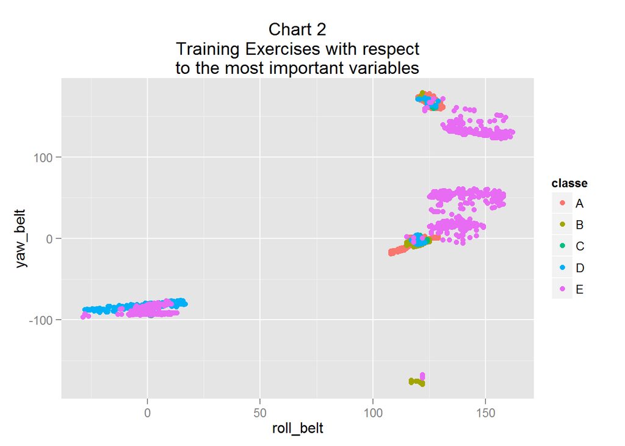

```r
        varImportance <- data.frame(fit_rf$finalModel$importance)
        varImportance$names <- rownames (varImportance )
        varImportance <- tbl_df(varImportance )
        varImportance <- varImportance %>%
                            arrange(  desc(MeanDecreaseGini) )

        ggplot (  training , aes( x= roll_belt , y= yaw_belt , color=  classe ) ) +
          geom_point( )+
          labs(title= "Chart 2\nTraining Exercises with respect\nto the most important variables")
```

## FINAL PREDICTION Final predition on test set

We show the cross validation accuracy of each model.

```r
    kable( model_accuracy , digit= 2 )
```

```
##
##
## |model                | accuracy|
## |:--------------------|--------:|
## |modal benchmark      |     0.28|
## |prop.prob. benchmark |     0.21|
## |GLM stepwise         |     0.74|
## |GLM stepwise PCA     |     0.52|
## |random forest        |     0.98|
```

We select the model with the best accuracy to make the final prediction.

```r
    model_accuracy[which.max(model_accuracy$accuracy),]
```

```
##           model accuracy
## 5 random forest   0.9786
```

We train the random forest on the full training set and then predict the test set observation.

```r
      set.seed( 777 )
      fit_rf_final <- randomForest( classe~ .  , data= training_full , mtry= 10 )

      answers <-   predict ( fit_rf_final , test_full )
```

END OF CODE